# Metin madenciliği yöntemiyle matrix(1999) filminin incelenmesi

## Giriş

Matrix filmindeki karekterlerin dialoglarının metin madenciliği yöntemleriyle analiz edilerek tutarlı anlamlar keşferederek uygun görselleştirme teknikleriyle anlatmakdır.

## Analizde gereken kütüphaneler

```r
library(tidyverse)
library(tm)
library(wordcloud)
library(wordcloud2)
library(tidytext)
library(reshape2)
library(RWeka)
library(knitr)
library(gridExtra)
library(grid)
library(magick)
library(memery)
library(ggimage)
library(igraph)
library(ggraph)
```

## Veri seti hakkında bilgi ve veri setinin yüklenmesi

Veri Seti, yonetmenligini Lana Wachowski ve Lilly Wachowski’nin ustlendigi 1999 yapimi aksiyon-bilimkurgu türündeki The Matrix filmine ait karakter diyolaglarini icermektedir.

Veri seti kaynağı: https://www.scripts.com/script/the_matrix_84

Veri seti ilgili sayfadan alınarak uygun analize uygun formata getirilmiştir.

```r
matrix <- read_csv("C:/Users/Fatih ekici/Downloads/matrix.csv")
matrix[matrix$character=="MORPHEUS (V.O.)",]="MORPHEUS"
```

### Veri Setinin Özellikleri

```r
summary(matrix) #veriseti özeti
```

```
##   character          dialogues
##  Length:845         Length:845
##  Class :character   Class :character
##  Mode  :character   Mode  :character
```

```r
head(matrix) #ilk 6 satır
```

```
## # A tibble: 6 x 2
##   character dialogues
##   <chr>     <chr>
## 1 MAN       Yeah
## 2 WOMAN     Is everything in place?
## 3 TRINITY   I said, is everything in place?
## 4 CYPHER    You weren't supposed to relieve me.
## 5 TRINITY   I know but I felt like taking a shift.
## 6 CYPHER    You like him, don't you?  You like watching him?
```

```r
sum(is.na(matrix)) #eksik gözlem
```

```
## [1] 0
```

Veri seti karekterin ve karektere ait metni içeren 2 değişkenden oluşmaktadır.Ve 845 adet metin parçası bulunmaktadır.Veride eksik gözlem bulunmamaktadır.

# Kantitatif Veri analizi

**En fazla diyaloğa sahip karekter kimdir?**

En çok söz hakkına sahip kişiyi tespit edelim.

[figure not shown]

```r
# En fazla diyaloğa sahip ilk 15 karakter.(Mutlak-Tam Değerler)
matrix %>%
  count(character) %>% #karekter sayıları
  arrange(desc(n)) %>% #büyükten küçüğe sıralama
  slice(1:15) %>% #ilk 15 kişi
  ggplot(aes(x=reorder(character, n), y=n)) + #büyükten küçüğe grafik
  geom_bar(stat="identity", aes(fill=n), show.legend=FALSE) +  #bar grafiği
  geom_label(aes(label=n)) + #metin sayısını gösterme
  scale_fill_gradient(low="lightgreen", high="darkgreen")  + #renkler
  labs(x="Karakterler", y="Diyalog",
       title="Karakterlerin Diyalog Frekansları") +
  coord_flip() +
  theme_bw()

# Görselleştirmedeki görüntü.
image <- image_read("https://stickerart.com.au/images/temp/images-products-0601-0704-w285-c5.gif")
grid.raster(image, x=0.9, y=0.35, height=0.50)
```

```r
matrix %>%
  count(character) #karekter sayıları
```

```
## # A tibble: 31 x 2
##    character       n
##    <chr>       <int>
##  1 AGENT BROWN     8
##  2 AGENT JONES    15
##  3 AGENT SMITH    63
##  4 APOC           10
##  5 BIG COP         2
##  6 CHOI            8
##  7 COP             2
##  8 CYPHER         55
##  9 DOZER           5
## 10 DUJOUR          1
## # ... with 21 more rows
```

Görünen o ki seçilmiş kişimiz ve morpheus en konuşkan kişiler.Bu görseli aynı zamanda oranlara göre gösterebiliriz.

[figure not shown]

```r
# Top 15 characters with more dialogues (relative values)
matrix %>%
  count(character) %>%
  arrange(desc(n)) %>%
  slice(1:15) %>%
  mutate(Percentage=n/nrow(matrix)) %>%
  ggplot(aes(x=reorder(character, Percentage), y=Percentage)) +
  geom_bar(stat="identity", aes(fill=Percentage), show.legend=FALSE) +
  geom_label(aes(label=paste0(round(Percentage*100, 2), "%"))) +
  scale_y_continuous(labels=scales::percent) +
  scale_fill_gradient(low="blue", high="red") +
  labs(x="Character", y="Lines of dialogue (%)",
       title="Lines of dialogue per character (relative values)") +
  coord_flip() +
  theme_bw()

# Image in the visualization
image <- image_read("https://stickeroid.com/uploads/pic/skurd/thumb/stickeroid_5bf575c7af988.png")
grid.raster(image, x=0.85, y=0.26, height=0.34)
```

# Duygu Analizi

Duygu analizi konusunu ele alalım. Metin madenciliği araçlarını, metnin duygusal içeriğine programlı olarak yaklaşmak için kullanabiliriz.

## Tokenezation

Burda 1 kelimelik tokenler

```r
tokens <- matrix %>%
  mutate(dialogues=as.character(matrix$dialogues)) %>%
  unnest_tokens(word, dialogues) #Teklimelik tokenler oluşturma
head(tokens)
```

```
## # A tibble: 6 x 2
##   character word
##   <chr>     <chr>
## 1 MAN       yeah
## 2 WOMAN     is
## 3 WOMAN     everything
## 4 WOMAN     in
## 5 WOMAN     place
## 6 TRINITY   i
```

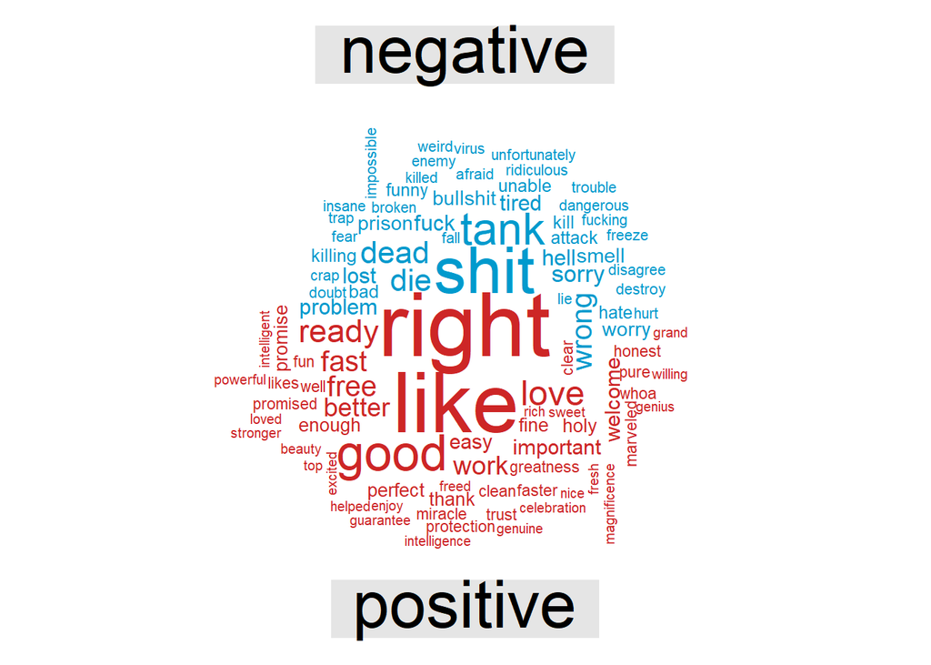

```r
# Positive and negative words
tokens %>%
  inner_join(get_sentiments("bing")) %>% #sözlük kelimelerini seçme
  count(word, sentiment, sort=TRUE) %>% #kelimeleri sayıp sıralama
  acast(word ~ sentiment, value.var="n", fill=0) %>% #kelime sayısı değişkeni renklendirme için
  comparison.cloud(colors=c("deepskyblue3", "firebrick3"), max.words=100) # cloud çizme
```

Bu sayede en çok tekrar eden olumlu ve olumsuz kelimelere erişmiş olduk.

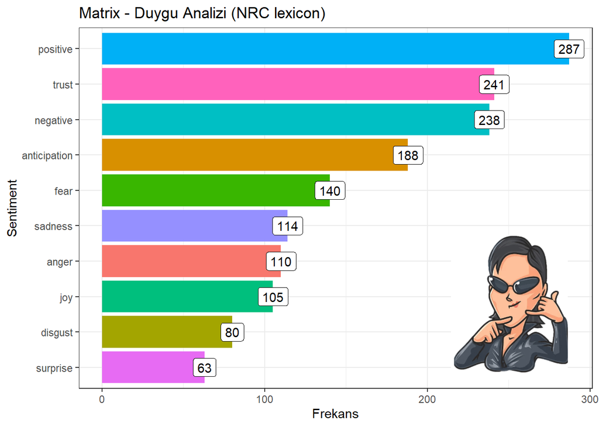

```r
# Her duygu ile ilişkili frekans
sentiments <- tokens %>%
  inner_join(get_sentiments("nrc")) %>%
  count(sentiment, sort=TRUE)

# Görselleştirme
ggplot(data=sentiments, aes(x=reorder(sentiment, n), y=n)) +
  geom_bar(stat="identity", aes(fill=sentiment), show.legend=FALSE) +
  geom_label(label=sentiments$n) +
  labs(x="Sentiment", y="Frekans",
       title="Matrix - Duygu Analizi (NRC lexicon)") +
  coord_flip() +
  theme_bw()

# Görselleştirmedeki Görüntü
image <- image_read("C:/Users/Fatih ekici/Desktop/Adsız.png")
grid.raster(image, x=0.85, y=0.28, height=0.34)
```

[figure not shown]

```r
# Her duygu için en sık kullanılan 10 terim
 tokens %>%
  inner_join(get_sentiments("nrc")) %>% #nrc duygu sözlüğü
  count(sentiment, word, sort=TRUE) %>% #kelimeleri sayma
  group_by(sentiment) %>% #duygulara göre gruplama
  arrange(desc(n)) %>% #büyükten küçüğe sıralam
  slice(1:10) %>% # en çok görünen 10 duygu
  ggplot(aes(x=reorder(word, n), y=n)) +
  geom_col(aes(fill=sentiment), show.legend=FALSE) +
  theme(axis.text.x=element_text(angle=45, hjust=1)) +
  facet_wrap(~sentiment, scales="free_y") +
  labs(y="Sıklık", x="Kelimeler",
       title="Her duygu için en yaygın terimler (NRC sözlüğü)") +
  coord_flip() +
  theme_bw()

# Görselleştirmedeki Görüntü
image <- image_read("https://d1yjjnpx0p53s8.cloudfront.net/styles/logo-thumbnail/s3/0002/0080/brand.gif?itok=aUkgy7w3")
grid.raster(image, x=0.78, y=0.15, height=0.35)
```

[figure not shown]

```r
# Daha fazla diyalog ile En İyi 10 karakter için Duygu Analizi
tokens %>%
  filter(character %in% c("NEO","MORPHEUS","TRINITY","TANK","AGENT SMITH",
                     "CYPHER","ORACLE","AGENT JONES","SWITCH","APOC")) %>% #karekterler
  inner_join(get_sentiments("nrc")) %>% #duygu sözlüğü
  count(character, sentiment, sort=TRUE) %>% #karekterleri sayma
  ggplot(aes(x=sentiment, y=n)) + #plot
  geom_col(aes(fill=sentiment), show.legend=FALSE) + #bar grafiği
  facet_wrap(~character, scales="free_x") + #parçalara ayırma
  labs(x="Duygu", y="Sıklık",
       title="Her karakter için Duygu Analizi (NRC sözlüğü)") +
  coord_flip() +
  theme_bw()

# Görselleştirmedeki Görüntü
image <- image_read("http://2.bp.blogspot.com/-egyhR3uFA8s/VNyWNSNfKhI/AAAAAAAAARc/LBOHM3itg-s/s1600/Screen%2BShot%2B2015-02-12%2Bat%2B12.00.34.png")
grid.raster(image, x=0.78, y=0.15, height=0.25)
```

# metin temizleme ve kelime frekansları sıralama

En çok tekrar eden kelimeleri ve karekterlere göre kelime sıklıklarını keşfedeceğiz.BU işlemlerde tek kelime sıralamalarını düzgün gösterebilmek için diyaloglardaki stopwordsleri kaldırmamız noktalama işaretlerini silmemiz gerekecektir.Yapılması gereken işlemleri yapmak için bir kaç adet fonksiyon tanımlayacağız bu fonksiyonlarıda işlemlere göre seçerek diyalogları analize hazır hale getireceğiz.

```r
# Text transformations
cleanCorpus <- function(corpus){

  corpus.tmp <- tm_map(corpus, removePunctuation)
  corpus.tmp <- tm_map(corpus.tmp, stripWhitespace)
  corpus.tmp <- tm_map(corpus.tmp, content_transformer(tolower))
  v_stopwords <- c(stopwords("english"), c("thats","weve","hes","theres","ive","im",
                                           "will","can","cant","dont","youve","us",
                                           "youre","youll","theyre","whats","didnt"))
  corpus.tmp <- tm_map(corpus.tmp, removeWords, v_stopwords)
  corpus.tmp <- tm_map(corpus.tmp, removeNumbers)
  return(corpus.tmp)

}
```

Tanımlamış olduğumuz cleanCorpus fonksiyonu veri setindeki noktalama işaretlerini boşlukları büyük harfleri küçük harflere dönüştürme işlemini yapacaktır.Son olarak stopwords ve sayıların silinmesi aşamasından sonra veri setini temiz hale getirmiş olucaktır.

```r
# Most frequent terms
frequentTerms <- function(text){

  s.cor <- VCorpus(VectorSource(text))
  s.cor.cl <- cleanCorpus(s.cor)
  s.tdm <- TermDocumentMatrix(s.cor.cl)
  s.tdm <- removeSparseTerms(s.tdm, 0.999)
  m <- as.matrix(s.tdm)
  word_freqs <- sort(rowSums(m), decreasing=TRUE)
  dm <- data.frame(word=names(word_freqs), freq=word_freqs)
  return(dm)

}
```

Bu aşamada tanımlanan fonksiyon veri setinden en çok tekrar eden kelimelerin tablosunu oluşturur.Veriseti önce corpus dosyası haline getirilir.ardından cleanCorpus fonksiyonu çalıştırılır Daha sonra veriyi tdm(Term Document Matrix) haline getirerek çok az rastlanan kelimeleri siliyoruz.Daha sonra yeni bir değişken oluşturarak en çok tekrar eden kelimeleri içeren bir dosya oluşturuyoruz. ve frekans tablomuz oluşuyor.

```r
# Define bigram tokenizer
tokenizer2  <- function(x){

  NGramTokenizer(x, Weka_control(min=2, max=2))

}

# Define trigram tokenizer
tokenizer3  <- function(x){

  NGramTokenizer(x, Weka_control(min=3, max=3))

}
```

r_weka paketiyle tokenleri tekrar eden 2 li ve 3 lü kelimeleri bulması adına fonksiyon adına tanımlıyoruz.

```r
# Most frequent bigrams
frequentBigrams <- function(text){

  s.cor <- VCorpus(VectorSource(text))
  s.cor.cl <- cleanCorpus(s.cor)
  s.tdm <- TermDocumentMatrix(s.cor.cl, control=list(tokenize=tokenizer2))
  s.tdm <- removeSparseTerms(s.tdm, 0.999)
  m <- as.matrix(s.tdm)
  word_freqs <- sort(rowSums(m), decreasing=TRUE)
  dm <- data.frame(word=names(word_freqs), freq=word_freqs)
  return(dm)}

# Most frequent trigrams
frequentTrigrams <- function(text){

  s.cor <- VCorpus(VectorSource(text))
  s.cor.cl <- cleanCorpus(s.cor)
  s.tdm <- TermDocumentMatrix(s.cor.cl, control=list(tokenize=tokenizer3))
  s.tdm <- removeSparseTerms(s.tdm, 0.999)
  m <- as.matrix(s.tdm)
  word_freqs <- sort(rowSums(m), decreasing=TRUE)
  dm <- data.frame(word=names(word_freqs), freq=word_freqs)
  return(dm)

}
```

en çok tekrar eden 2li ve 3lü kelime çiftlerinin tablosunu oluşturan fonksiyonu tanımladık.

2’li kelime çiftleri

```r
# Bigrams - The Fellowship of the Ring
bigrams1 <- frequentBigrams(iconv(matrix$dialogues, from="UTF-8", to="ASCII//TRANSLIT"))[1:10,]

plot1 <- ggplot(data=bigrams1, aes(x=reorder(word, freq), y=freq)) +
  geom_bar(stat="identity", aes(fill=freq), show.legend=FALSE) +
  geom_label(label=bigrams1$freq) +
  scale_fill_gradient(low="darkorange", high="darkorange4") +
  labs(x="ikilemeler", y="Sıklık") +
  coord_flip() +
  theme_bw()
```

3’lü kelime çiftleri

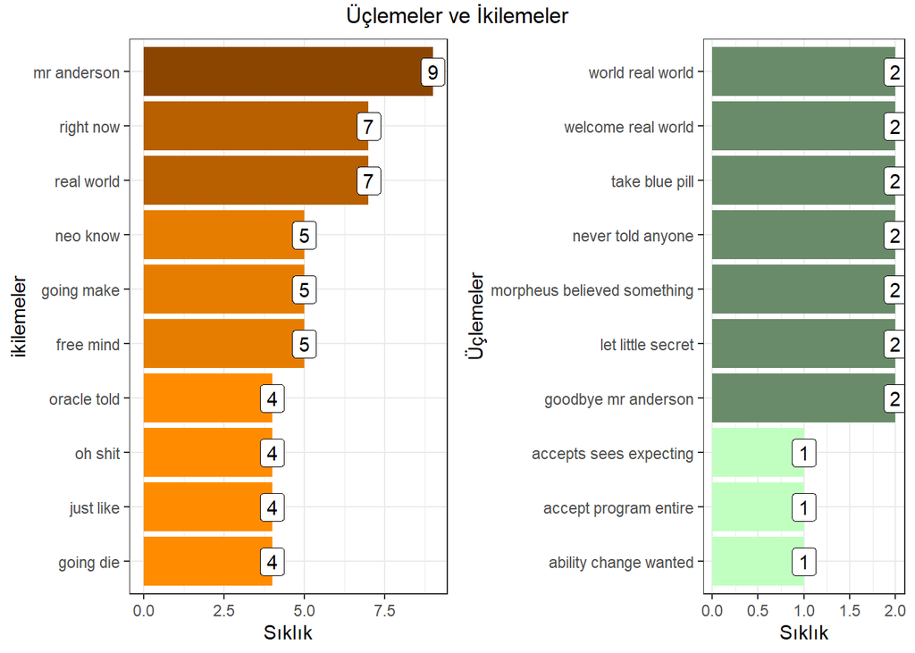

```r
# Trigrams - The Fellowship of the Ring
trigrams1 <- frequentTrigrams(iconv(matrix$dialogues, from="UTF-8", to="ASCII//TRANSLIT"))[1:10,]

plot2 <- ggplot(data=trigrams1, aes(x=reorder(word, freq), y=freq)) +
  geom_bar(stat="identity", aes(fill=freq), show.legend=FALSE) +
  geom_label(label=trigrams1$freq) +
  scale_fill_gradient(low="darkseagreen1", high="darkseagreen4") +
  labs(x="Üçlemeler", y="Sıklık") +
  coord_flip() +
  theme_bw()

# Subplot
grid.arrange(plot1, plot2, ncol=2, top="Üçlemeler ve İkilemeler")
```

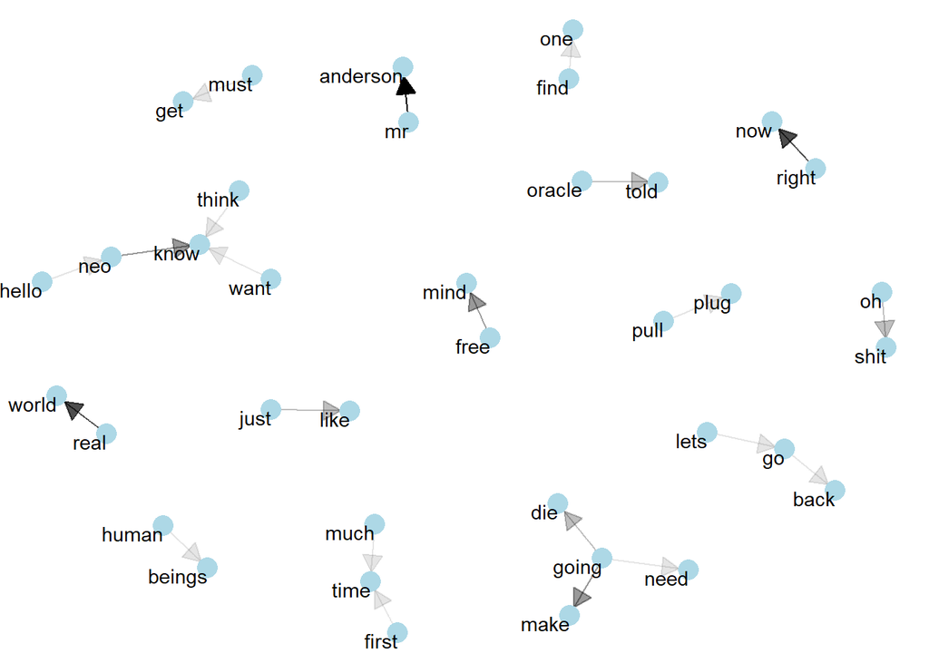

```r
# ikilemeler
bigrams <- frequentBigrams(iconv(matrix$dialogues, from="UTF-8", to="ASCII//TRANSLIT"))

# Grafik oluşturmak için farklı sütunlardaki kelimeler
bigrams_separated <- bigrams %>%
  separate(word, c("word1", "word2"), sep=" ")

# igraph objesi oluşturmak
bigrams_graph <- bigrams_separated %>%
  filter(freq>2) %>%
  graph_from_data_frame()

set.seed(2016)

# ok işaretlerini oluşturmak
a <- grid::arrow(type="closed", length=unit(0.15, "inches"))

# ggraph görselleştirme
ggraph(bigrams_graph, layout="fr") +
  geom_edge_link(aes(edge_alpha=freq), show.legend = FALSE,
                 arrow=a, end_cap=circle(0.07, 'inches')) +
  geom_node_point(color="lightblue", size=5) +
  geom_node_text(aes(label=name), vjust=1, hjust=1) +
  theme_void()
```

```r
# Stopwords
mystopwords <- data_frame(word=c(stopwords("english"),
                                 c("thats","weve","hes","theres","ive","im",
                                   "will","can","cant","dont","youve","us",
                                   "youre","youll","theyre","whats","didnt", "â","mr")))
```

[figure not shown]

```r
# Anahtar sözcük içermeyen tokenler
top.chars.tokens <- matrix %>%
  mutate(dialogue=as.character(matrix$dialogues)) %>%
  filter(character %in% c("NEO","MORPHEUS","TRINITY","TANK","AGENT SMITH",
                     "CYPHER","ORACLE")) %>%
  unnest_tokens(word, dialogue) %>%
  anti_join(mystopwords, by="word")

# Her karakter için en sık kullanılan kelimeler

top.chars.tokens %>%
  count(character, word) %>%
  group_by(character) %>%
  arrange(desc(n)) %>%
  slice(1:10) %>%
  ungroup() %>%
  mutate(word2=factor(paste(word, character, sep="__"),
                       levels=rev(paste(word, character, sep="__"))))%>%
  ggplot(aes(x=word2, y=n)) +
  geom_col(aes(fill=character), show.legend=FALSE) +
  facet_wrap(~character, scales="free_y") +
  labs(x="DUYGULAR", y="SIKLIK",
       title="Her karekter için en sık kullanılan kelimeler") +
  scale_x_discrete(labels=function(x) gsub("__.+$", "", x)) +
  coord_flip() +
  theme_bw()
```